# PrepPlankton_scaled

Phoebe.Woodworth-Jefcoats@noaa.gov

8/24/2020

## Purpose

The purpose of this script is to create scaled resource spectra for the therMizer FishMIP runs. There are four climate scenarios:

- picontrol: pre-industrial climate as simulated by the Earth System Models (ESMs)
- historical: historical climate as simulated by the ESMs, starting in 1950
- ssp126: SSP1-RCP2.6 climate as simulated by the ESMs
- ssp585" SSP5-RCP8.5 climate as simulated by the ESMs

and both ssp126 and ssp585 will be appended to historical. Note that only the years 1950 - 2100 are needed.

## Plankton community

To facilitate comparison with the previous FishMIP simulations, we’ll use the same approach as with the previous FishMIP contribution, which follows that of [Woodworth-Jefcoats et al. 2019](https://www.frontiersin.org/articles/10.3389/fmars.2019.00383/full). We’ll use the same assumptions about plankton size classes, as this doesn’t appear to have changed between CMIP5 and CMIP6 for either model we’re using. The GFDL-ESM4 includes small, large, and diazotrophic phytoplankton, as well as three classes of zooplankton [Dunne et al. 2020](https://agupubs.onlinelibrary.wiley.com/doi/abs/10.1029/2019MS002015). The IPSL-CM6A-LR includes nanophytoplankton, diatoms, microzooplankton, and mesozooplankton [Boucher et al. 2020](https://agupubs.onlinelibrary.wiley.com/doi/10.1029/2019MS002010).

## Preparing CMIP6 model output for therMizer

The general approach we’ll take to convert the CMIP6 plankton data in to resource spectra includes these steps:

- Convert from moles C to grams wet weight
  - mol C m<sup>-2</sup> $\times$ 12.011 g mol<sup>-1</sup> = g C m<sup>-2</sup>
  - g C m<sup>-2</sup> $\times$ 10 = gww m<sup>-2</sup>
- Determine total biomass over model domain
  - gww m<sup>-2</sup> $\times$ km<sup>2</sup> $\times$ 10<sup>6</sup> = gww
- Calculate abundance in each plankton size class
  - gww / median size of size class = abundance in size class
  - To convert size from $\mu$m ESD to gww: (4/3) $\times$ $\pi$ $\times$ (0.5 $\times$ ESD $\times$ 0.0001)<sup>3</sup> = gww
- Determine linear abundance spectra
- Use the slope and intercept from the linear abundance to determine the resource spectra over the full size range
- If necessary, scale the resulting resource spectra to obtain similiar levels of food limition as those that arise from the mizer-calculated resource spectra

Note that the CMIP6 data don’t include values for the smaller phytoplankton size classes. These will have to be derived by subtracting the larger size class from total plankton.

```r
# First, let's create the values we'll need.  See Woodworth-Jefcoats et al. 2019 for references.
#   nano = 2 - 20 um ESD (mid-point size = 11 um ESD)
#   smallGFDL = 0.2 - 5 um ESD (mid-point size = 2.4 um ESD)
#   large (diatoms and diazotrophs) = 20 - 200 um ESD (mid-point size = 110 um ESD)
#   largeGDFL = 5 - 200 um ESD (mid-point = 102.5 um ESD)
#   zmicro = 2 - 20 um ESD (mid-point size = 11 um ESD)
#   zmeso = 20 - 500 um ESD (mid-point size = 260 um ESD)

nano <- (4/3)*pi*((0.5*11*0.0001)^3)
smallGFDL <- (4/3)*pi*((0.5*2.4*0.0001)^3)
large <- (4/3)*pi*((0.5*110*0.0001)^3)
largeGFDL <- (4/3)*pi*((0.5*102.5*0.0001)^3)
zmicro <- (4/3)*pi*((0.5*11*0.0001)^3)
zmeso <- (4/3)*pi*((0.5*260*0.0001)^3)

area = 20527092 * 10^6

# Load data
GFDL_picon <- read.csv("Hawaii_GFDL-ESM4_picontrol_annual_1601_2100.csv", header = TRUE)
GFDL_hist <- read.csv("Hawaii_GFDL-ESM4_historical_annual_1850_2014.csv", header = TRUE)
GFDL_ssp126 <- read.csv("Hawaii_GFDL-ESM4_ssp126_annual_2015_2100.csv", header = TRUE)
GFDL_ssp585 <- read.csv("Hawaii_GFDL-ESM4_ssp585_annual_2015_2100.csv", header = TRUE)

IPSL_picon <- read.csv("Hawaii_IPSL-CM6A-LR_picontrol_annual_1601_2100.csv", header = TRUE)
IPSL_hist <- read.csv("Hawaii_IPSL-CM6A-LR_historical_annual_1850_2014.csv", header = TRUE)
IPSL_ssp126 <- read.csv("Hawaii_IPSL-CM6A-LR_ssp126_annual_2015_2100.csv", header = TRUE)
IPSL_ssp585 <- read.csv("Hawaii_IPSL-CM6A-LR_ssp585_annual_2015_2100.csv", header = TRUE)

# Calculate numerical abundance in each size class, for only the years we're interested in
GFDL_picon_yrs <- which(GFDL_picon$Date..yyyy. >= 1950)
IPSL_picon_yrs <- which(IPSL_picon$Date..yyyy. >= 1950)
GFDL_hist_yrs <- which(GFDL_hist$Date..yyyy. >= 1950)
IPSL_hist_yrs <- which(IPSL_hist$Date..yyyy. >= 1950)

GFDL_picon_sm_num <- ((GFDL_picon$phyc.vint..mol.m.2.[GFDL_picon_yrs] - GFDL_picon$phydiat.vint..mol.m.2.[GFDL_picon_yrs]) * 12.011 * 10 * area) / smallGFDL
GFDL_picon_lg_num <- (GFDL_picon$phydiat.vint..mol.m.s.[GFDL_picon_yrs] * 12.011 * 10 * area) / largeGFDL
GFDL_picon_zmicro_num <- (GFDL_picon$zmicro.vint..mol.m.2.[GFDL_picon_yrs] * 12.011 * 10 * area) / zmicro
GFDL_picon_zmeso_num <- (GFDL_picon$zmeso.vint..mol.m.2.[GFDL_picon_yrs] * 12.011 * 10 * area) / zmeso

GFDL_hist_sm_num <- ((GFDL_hist$phyc.vint..mol.m.2.[GFDL_hist_yrs] - GFDL_hist$phydiat.vint..mol.m.2.[GFDL_hist_yrs]) * 12.011 * 10 * area) / smallGFDL
GFDL_hist_lg_num <- (GFDL_hist$phydiat.vint..mol.m.s.[GFDL_hist_yrs] * 12.011 * 10 * area) / largeGFDL
GFDL_hist_zmicro_num <- (GFDL_hist$zmicro.vint..mol.m.2.[GFDL_hist_yrs] * 12.011 * 10 * area) / zmicro
GFDL_hist_zmeso_num <- (GFDL_hist$zmeso.vint..mol.m.2.[GFDL_hist_yrs] * 12.011 * 10 * area) / zmeso

GFDL_ssp126_sm_num <- ((GFDL_ssp126$phyc.vint..mol.m.2. - GFDL_ssp126$phydiat.vint..mol.m.2.) * 12.011 * 10 * area) / smallGFDL
GFDL_ssp126_lg_num <- (GFDL_ssp126$phydiat.vint..mol.m.s. * 12.011 * 10 * area) / largeGFDL
GFDL_ssp126_zmicro_num <- (GFDL_ssp126$zmicro.vint..mol.m.2. * 12.011 * 10 * area) / zmicro
GFDL_ssp126_zmeso_num <- (GFDL_ssp126$zmeso.vint..mol.m.2. * 12.011 * 10 * area) / zmeso

GFDL_ssp585_sm_num <- ((GFDL_ssp585$phyc.vint..mol.m.2. - GFDL_ssp585$phydiat.vint..mol.m.2.) * 12.011 * 10 * area) / smallGFDL
GFDL_ssp585_lg_num <- (GFDL_ssp585$phydiat.vint..mol.m.s. * 12.011 * 10 * area) / largeGFDL
GFDL_ssp585_zmicro_num <- (GFDL_ssp585$zmicro.vint..mol.m.2. * 12.011 * 10 * area) / zmicro
GFDL_ssp585_zmeso_num <- (GFDL_ssp585$zmeso.vint..mol.m.2. * 12.011 * 10 * area) / zmeso

IPSL_picon_nano_num <- ((IPSL_picon$phyc.vint..mol.m.2.[IPSL_picon_yrs] - IPSL_picon$phydiat.vint..mol.m.2.[IPSL_picon_yrs]) * 12.011 * 10 * area) / nano
IPSL_picon_lg_num <- (IPSL_picon$phydiat.vint..mol.m.s.[IPSL_picon_yrs] * 12.011 * 10 * area) / large
IPSL_picon_zmicro_num <- (IPSL_picon$zmicro.vint..mol.m.2.[IPSL_picon_yrs] * 12.011 * 10 * area) / zmicro
IPSL_picon_zmeso_num <- (IPSL_picon$zmeso.vint..mol.m.2.[IPSL_picon_yrs] * 12.011 * 10 * area) / zmeso

IPSL_hist_nano_num <- ((IPSL_hist$phyc.vint..mol.m.2.[IPSL_hist_yrs] - IPSL_hist$phydiat.vint..mol.m.2.[IPSL_hist_yrs]) * 12.011 * 10 * area) / nano
IPSL_hist_lg_num <- (IPSL_hist$phydiat.vint..mol.m.s.[IPSL_hist_yrs] * 12.011 * 10 * area) / large
IPSL_hist_zmicro_num <- (IPSL_hist$zmicro.vint..mol.m.2.[IPSL_hist_yrs] * 12.011 * 10 * area) / zmicro
IPSL_hist_zmeso_num <- (IPSL_hist$zmeso.vint..mol.m.2.[IPSL_hist_yrs] * 12.011 * 10 * area) / zmeso

IPSL_ssp126_nano_num <- ((IPSL_ssp126$phyc.vint..mol.m.2. - IPSL_ssp126$phydiat.vint..mol.m.2.) * 12.011 * 10 * area) / nano
IPSL_ssp126_lg_num <- (IPSL_ssp126$phydiat.vint..mol.m.s. * 12.011 * 10 * area) / large
IPSL_ssp126_zmicro_num <- (IPSL_ssp126$zmicro.vint..mol.m.2. * 12.011 * 10 * area) / zmicro
IPSL_ssp126_zmeso_num <- (IPSL_ssp126$zmeso.vint..mol.m.2. * 12.011 * 10 * area) / zmeso

IPSL_ssp585_nano_num <- ((IPSL_ssp585$phyc.vint..mol.m.2. - IPSL_ssp585$phydiat.vint..mol.m.2.) * 12.011 * 10 * area) / nano
IPSL_ssp585_lg_num <- (IPSL_ssp585$phydiat.vint..mol.m.s. * 12.011 * 10 * area) / large
IPSL_ssp585_zmicro_num <- (IPSL_ssp585$zmicro.vint..mol.m.2. * 12.011 * 10 * area) / zmicro
IPSL_ssp585_zmeso_num <- (IPSL_ssp585$zmeso.vint..mol.m.2. * 12.011 * 10 * area) / zmeso

# Combine size classes for initial linear spectra
GFDL_x <- log10(c(smallGFDL, largeGFDL, zmicro, zmeso))
IPSL_x <- log10(c(nano, large, zmicro, zmeso))
```

In order to make sure that the spectra we create from the CMIP6 data match our therMizer simulations, we’re going to load `mizer` and generate a parameter object. This will allow us to use `w_full` for the x values in the new linear spectra.

```r
library(mizer)

# Load species parameters
species_params <- read.csv('NPac_species_params.csv')

# Load interaction matrix
inter <- read.csv('inter_NPAC.csv', row.names = 1)
inter <- as(inter, "matrix")

# Create the params object
# Since we're not going to run mizer, we'll ignore the column about the selectivity function so we don't get an error
params <- newMultispeciesParams(species_params[,1:14], interaction = inter, min_w_pp = 1e-14, no_w = 100, kappa = 1e12, w_pp_cutoff = 455400 * 1.1)
```

Now we can carry on with the CMIP6 data:

- We’ll begin with the same scaling we used for the previous FishMIP contribution (scale slope by 1.1 and intercept by 0.9)
- Also try scaling as in [Woodworth-Jefcoats et al. 2019](https://www.frontiersin.org/articles/10.3389/fmars.2019.00383/full) (scale slope by 1.2 and intercept by 0.8)
- Trying a combination of the two (scale slope by 1.1 and intercept by 0.8)

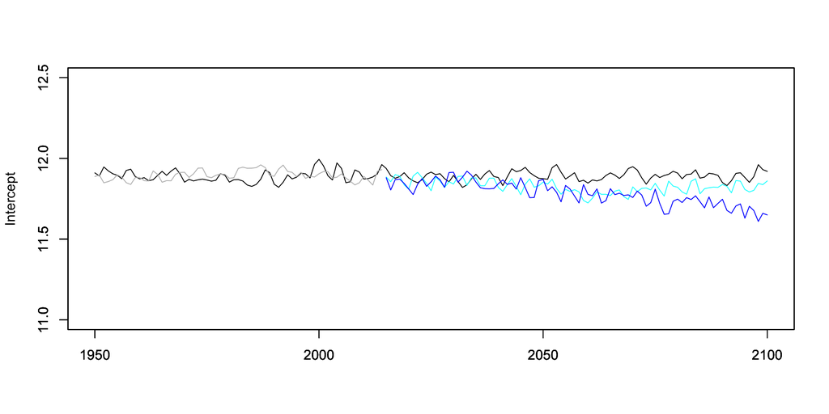

```r
# Create arrays to fill
GFDL_picon_out <- array(numeric(), c(2100-1950+1,length(params@w_full))) # years 1950 - 2100 by size
GFDL_hist_out <- array(numeric(), c(2014-1950+1,length(params@w_full))) # years 1950 - 2014 by size
GFDL_ssp126_out <- array(numeric(), c(2100-2015+1,length(params@w_full))) # years 2015 - 2100 by size
GFDL_ssp585_out <- array(numeric(), c(2100-2015+1,length(params@w_full))) # years 2015 - 2100 by size

IPSL_picon_out <- array(numeric(), c(2100-1950+1,length(params@w_full))) # years 1950 - 2100 by size
IPSL_hist_out <- array(numeric(), c(2014-1950+1,length(params@w_full))) # years 1950 - 2014 by size
IPSL_ssp126_out <- array(numeric(), c(2100-2015+1,length(params@w_full))) # years 2015 - 2100 by size
IPSL_ssp585_out <- array(numeric(), c(2100-2015+1,length(params@w_full))) # years 2015 - 2100 by size

# We're also going to save the slopes and intercept from the linear fits, because this information is helpful in ensuring we've come up with something reasonable.
GFDL_picon_coefs <- array(numeric(), c(2100-1950+1,2)) # years 1950 - 2100 by 2 coefficients
GFDL_hist_coefs <- array(numeric(), c(2014-1950+1,2)) # years 1950 - 2014 by 2 coefficients
GFDL_ssp126_coefs <- array(numeric(), c(2100-2015+1,2)) # years 2015 - 2100 by 2 coefficients
GFDL_ssp585_coefs <- array(numeric(), c(2100-2015+1,2)) # years 2015 - 2100 by 2 coefficients

IPSL_picon_coefs <- array(numeric(), c(2100-1950+1,2)) # years 1950 - 2100 by 2 coefficients
IPSL_hist_coefs <- array(numeric(), c(2014-1950+1,2)) # years 1950 - 2014 by 2 coefficients
IPSL_ssp126_coefs <- array(numeric(), c(2100-2015+1,2)) # years 2015 - 2100 by 2 coefficients
IPSL_ssp585_coefs <- array(numeric(), c(2100-2015+1,2)) # years 2015 - 2100 by 2 coefficients


# Pre-industrial control runs
for (t in seq(1950, 2100, 1)){
  GFDL_picon_plankton <- log10(c(GFDL_picon_sm_num[t-1949], GFDL_picon_lg_num[t-1949], GFDL_picon_zmicro_num[t-1949], GFDL_picon_zmeso_num[t-1949]))
  IPSL_picon_plankton <- log10(c(IPSL_picon_nano_num[t-1949], IPSL_picon_lg_num[t-1949], IPSL_picon_zmicro_num[t-1949], IPSL_picon_zmeso_num[t-1949]))

  # Calculate the sloes and intercept for ESM size range
  GFDL_picon_lm <- lm(GFDL_picon_plankton ~ GFDL_x)
  IPSL_picon_lm <- lm(IPSL_picon_plankton ~ IPSL_x)

  # Expand to full size range, scaling slope and intercept
  full_x <- log10(params@w_full)

  GFDL_picon_out[t-1949,] <- GFDL_picon_lm$coefficients[2]*1.0 * full_x + GFDL_picon_lm$coefficients[1]*0.85
  IPSL_picon_out[t-1949,] <- IPSL_picon_lm$coefficients[2]*1.0 * full_x + IPSL_picon_lm$coefficients[1]*0.85

  # Keep track of the coefficients for the linear model
  GFDL_picon_coefs[t-1949,] <- GFDL_picon_lm$coefficients
  IPSL_picon_coefs[t-1949,] <- IPSL_picon_lm$coefficients
}

# Historical runs
for (t in seq(1950, 2014, 1)){
  GFDL_hist_plankton <- log10(c(GFDL_hist_sm_num[t-1949], GFDL_hist_lg_num[t-1949], GFDL_hist_zmicro_num[t-1949], GFDL_hist_zmeso_num[t-1949]))
  IPSL_hist_plankton <- log10(c(IPSL_hist_nano_num[t-1949], IPSL_hist_lg_num[t-1949], IPSL_hist_zmicro_num[t-1949], IPSL_hist_zmeso_num[t-1949]))

  # Calculate the sloes and intercept for ESM size range
  GFDL_hist_lm <- lm(GFDL_hist_plankton ~ GFDL_x)
  IPSL_hist_lm <- lm(IPSL_hist_plankton ~ IPSL_x)

  # Expand to full size range
  full_x <- log10(params@w_full)

  GFDL_hist_out[t-1949,] <- GFDL_hist_lm$coefficients[2]*1.0 * full_x + GFDL_hist_lm$coefficients[1]*0.85
  IPSL_hist_out[t-1949,] <- IPSL_hist_lm$coefficients[2]*1.0 * full_x + IPSL_hist_lm$coefficients[1]*0.85

  # Keep track of the coefficients for the linear model
  GFDL_hist_coefs[t-1949,] <- GFDL_hist_lm$coefficients
  IPSL_hist_coefs[t-1949,] <- IPSL_hist_lm$coefficients
}

# Projections
for (t in seq(2015, 2100, 1)){
  GFDL_ssp126_plankton <- log10(c(GFDL_ssp126_sm_num[t-2014], GFDL_ssp126_lg_num[t-2014], GFDL_ssp126_zmicro_num[t-2014], GFDL_ssp126_zmeso_num[t-2014]))
  IPSL_ssp126_plankton <- log10(c(IPSL_ssp126_nano_num[t-2014], IPSL_ssp126_lg_num[t-2014], IPSL_ssp126_zmicro_num[t-2014], IPSL_ssp126_zmeso_num[t-2014]))

  GFDL_ssp585_plankton <- log10(c(GFDL_ssp585_sm_num[t-2014], GFDL_ssp585_lg_num[t-2014], GFDL_ssp585_zmicro_num[t-2014], GFDL_ssp585_zmeso_num[t-2014]))
  IPSL_ssp585_plankton <- log10(c(IPSL_ssp585_nano_num[t-2014], IPSL_ssp585_lg_num[t-2014], IPSL_ssp585_zmicro_num[t-2014], IPSL_ssp585_zmeso_num[t-2014]))

  # Calculate the sloes and intercept for ESM size range
  GFDL_ssp126_lm <- lm(GFDL_ssp126_plankton ~ GFDL_x)
  IPSL_ssp126_lm <- lm(IPSL_ssp126_plankton ~ IPSL_x)

  GFDL_ssp585_lm <- lm(GFDL_ssp585_plankton ~ GFDL_x)
  IPSL_ssp585_lm <- lm(IPSL_ssp585_plankton ~ IPSL_x)

  # Expand to full size range
  full_x <- log10(params@w_full)

  GFDL_ssp126_out[t-2014,] <- GFDL_ssp126_lm$coefficients[2]*1.0 * full_x + GFDL_ssp126_lm$coefficients[1]*0.85
  IPSL_ssp126_out[t-2014,] <- IPSL_ssp126_lm$coefficients[2]*1.0 * full_x + IPSL_ssp126_lm$coefficients[1]*0.85

  GFDL_ssp585_out[t-2014,] <- GFDL_ssp585_lm$coefficients[2]*1.0 * full_x + GFDL_ssp585_lm$coefficients[1]*0.85
  IPSL_ssp585_out[t-2014,] <- IPSL_ssp585_lm$coefficients[2]*1.0 * full_x + IPSL_ssp585_lm$coefficients[1]*0.85

  # Keep track of the coefficients for the linear model
  GFDL_ssp126_coefs[t-2014,] <- GFDL_ssp126_lm$coefficients
  IPSL_ssp126_coefs[t-2014,] <- IPSL_ssp126_lm$coefficients

  GFDL_ssp585_coefs[t-2014,] <- GFDL_ssp585_lm$coefficients
  IPSL_ssp585_coefs[t-2014,] <- IPSL_ssp585_lm$coefficients

}

# Save for input into therMizer
# Time dimension
picon_times <- seq(1950,2100,1)
hist_times <- seq(1950,2014,1)
ssp_times <- seq(2015,2100,1)

# Size dimension
size <- params@w_full

# Create appropriately defined arrays
GFDL_picon_n_pp_array = array(NA, dim = c(length(picon_times), length(size)), dimnames = list(time = picon_times, w = size))
GFDL_hist_n_pp_array = array(NA, dim = c(length(hist_times), length(size)), dimnames = list(time = hist_times, w = size))
GFDL_ssp126_n_pp_array = array(NA, dim = c(length(ssp_times), length(size)), dimnames = list(time = ssp_times, w = size))
GFDL_ssp585_n_pp_array = array(NA, dim = c(length(ssp_times), length(size)), dimnames = list(time = ssp_times, w = size))

IPSL_picon_n_pp_array = array(NA, dim = c(length(picon_times), length(size)), dimnames = list(time = picon_times, w = size))
IPSL_hist_n_pp_array = array(NA, dim = c(length(hist_times), length(size)), dimnames = list(time = hist_times, w = size))
IPSL_ssp126_n_pp_array = array(NA, dim = c(length(ssp_times), length(size)), dimnames = list(time = ssp_times, w = size))
IPSL_ssp585_n_pp_array = array(NA, dim = c(length(ssp_times), length(size)), dimnames = list(time = ssp_times, w = size))

# Fill them
GFDL_picon_n_pp_array[,] <- GFDL_picon_out[,]
GFDL_hist_n_pp_array[,] <- GFDL_hist_out[,]
GFDL_ssp126_n_pp_array[,] <- GFDL_ssp126_out[,]
GFDL_ssp585_n_pp_array[,] <- GFDL_ssp585_out[,]

IPSL_picon_n_pp_array[,] <- IPSL_picon_out[,]
IPSL_hist_n_pp_array[,] <- IPSL_hist_out[,]
IPSL_ssp126_n_pp_array[,] <- IPSL_ssp126_out[,]
IPSL_ssp585_n_pp_array[,] <- IPSL_ssp585_out[,]

# Concatonate historical runs and projections
GFDL_CCscenario_126 <- rbind(GFDL_hist_n_pp_array, GFDL_ssp126_n_pp_array)
GFDL_CCscenario_585 <- rbind(GFDL_hist_n_pp_array, GFDL_ssp585_n_pp_array)

IPSL_CCscenario_126 <- rbind(IPSL_hist_n_pp_array, IPSL_ssp126_n_pp_array)
IPSL_CCscenario_585 <- rbind(IPSL_hist_n_pp_array, IPSL_ssp585_n_pp_array)

# Let's create some plots to make sure things look reasonable
plot(picon_times, GFDL_picon_coefs[,1]*0.85, type = "l", col = "black", xlim = c(1950, 2100), ylim = c(11,12.5), xlab = " ", ylab = " ")
par(new = TRUE)
plot(hist_times, GFDL_hist_coefs[,1]*0.85, type = "l", col = "grey", xlim = c(1950, 2100), ylim = c(11,12.5), xlab = " ", ylab = " ")
par(new = TRUE)
plot(ssp_times, GFDL_ssp126_coefs[,1]*0.85, type = "l", col = "cyan", xlim = c(1950, 2100), ylim = c(11,12.5), xlab = " ", ylab = " ")
par(new = TRUE)
plot(ssp_times, GFDL_ssp585_coefs[,1]*0.85, type = "l", col = "blue", xlim = c(1950, 2100), ylim = c(11,12.5), xlab = " ", ylab = "Intercept")
```

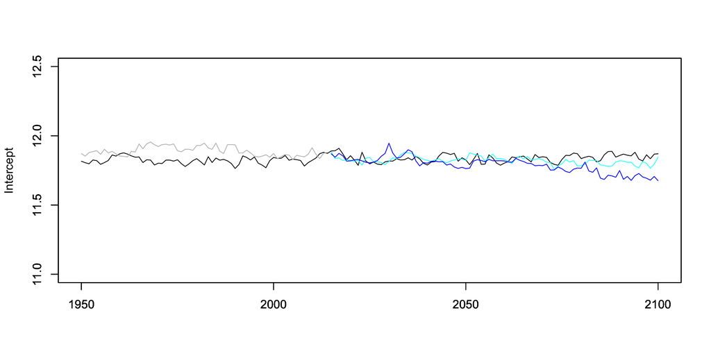

```r
plot(picon_times, IPSL_picon_coefs[,1]*0.85, type = "l", col = "black", xlim = c(1950, 2100), ylim = c(11,12.5), xlab = " ", ylab = " ")
par(new = TRUE)
plot(hist_times, IPSL_hist_coefs[,1]*0.85, type = "l", col = "grey", xlim = c(1950, 2100), ylim = c(11,12.5), xlab = " ", ylab = " ")
par(new = TRUE)
plot(ssp_times, IPSL_ssp126_coefs[,1]*0.85, type = "l", col = "cyan", xlim = c(1950, 2100), ylim = c(11,12.5), xlab = " ", ylab = " ")
par(new = TRUE)
plot(ssp_times, IPSL_ssp585_coefs[,1]*0.85, type = "l", col = "blue", xlim = c(1950, 2100), ylim = c(11,12.5), xlab = " ", ylab = "Intercept")
```

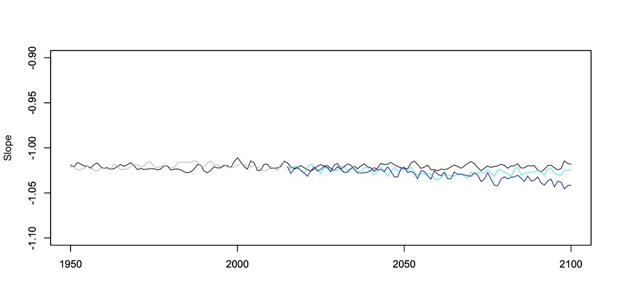

```r
plot(picon_times, GFDL_picon_coefs[,2]*1.0, type = "l", col = "black", xlim = c(1950, 2100), ylim = c(-1.1,-0.9), xlab = " ", ylab = " ")
par(new = TRUE)
plot(hist_times, GFDL_hist_coefs[,2]*1.0, type = "l", col = "grey", xlim = c(1950, 2100), ylim = c(-1.1,-0.9), xlab = " ", ylab = " ")
par(new = TRUE)
plot(ssp_times, GFDL_ssp126_coefs[,2]*1.0, type = "l", col = "cyan", xlim = c(1950, 2100), ylim = c(-1.1,-0.9), xlab = " ", ylab = " ")
par(new = TRUE)
plot(ssp_times, GFDL_ssp585_coefs[,2]*1.0, type = "l", col = "blue", xlim = c(1950, 2100), ylim = c(-1.1,-0.9), xlab = " ", ylab = "Slope")
```

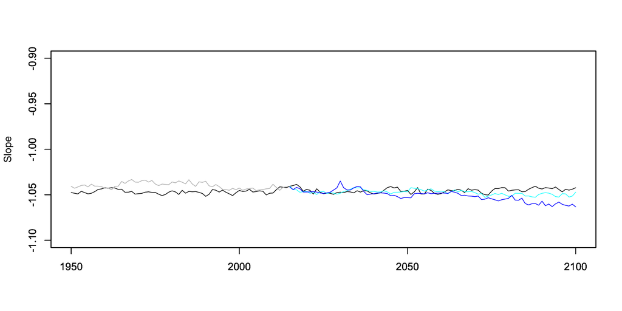

```r
plot(picon_times, IPSL_picon_coefs[,2]*1.0, type = "l", col = "black", xlim = c(1950, 2100), ylim = c(-1.1,-0.9), xlab = " ", ylab = " ")
par(new = TRUE)
plot(hist_times, IPSL_hist_coefs[,2]*1.0, type = "l", col = "grey", xlim = c(1950, 2100), ylim = c(-1.1,-0.9), xlab = " ", ylab = " ")
par(new = TRUE)
plot(ssp_times, IPSL_ssp126_coefs[,2]*1.0, type = "l", col = "cyan", xlim = c(1950, 2100), ylim = c(-1.1,-0.9), xlab = " ", ylab = " ")
par(new = TRUE)
plot(ssp_times, IPSL_ssp585_coefs[,2]*1.0, type = "l", col = "blue", xlim = c(1950, 2100), ylim = c(-1.1,-0.9), xlab = " ", ylab = "Slope")
```

That looks alright. And remarkably similar across both models… Let’s also plot the size spectra.

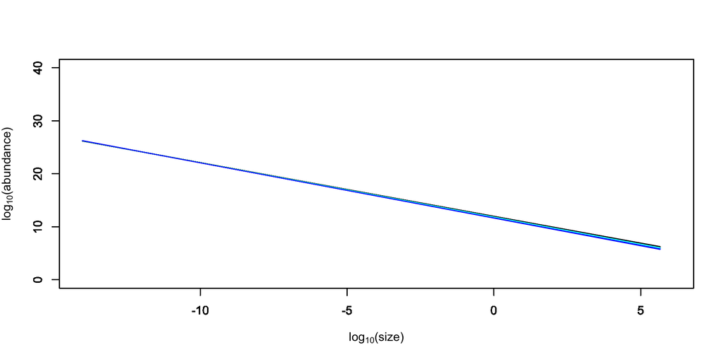

```r
# Plot spectra, looping through time steps
for (t in seq(1950,2099,1)){
  plot(log10(size), GFDL_picon_n_pp_array[t-1949,], type = "l", col = "black", xlim = c(-14,6), ylim = c(0,40), xlab = " ", ylab = " ")
  par(new = TRUE)
  plot(log10(size), GFDL_CCscenario_126[t-1949,], type = "l", col = "cyan", xlim = c(-14,6), ylim = c(0,40), xlab = " ", ylab = " ")
  par(new = TRUE)
  plot(log10(size), GFDL_CCscenario_585[t-1949,], type = "l", col = "blue", xlim = c(-14,6), ylim = c(0,40), xlab = " ", ylab = " ")
  par(new = TRUE)
}
plot(log10(size), GFDL_picon_n_pp_array[2100-1949,], type = "l", col = "black", xlim = c(-14,6), ylim = c(0,40), xlab = " ", ylab = " ")
par(new = TRUE)
plot(log10(size), GFDL_CCscenario_126[2100-1949,], type = "l", col = "cyan", xlim = c(-14,6), ylim = c(0,40), xlab = " ", ylab = " ")
par(new = TRUE)
plot(log10(size), GFDL_CCscenario_585[2100-1949,], type = "l", col = "blue", xlim = c(-14,6), ylim = c(0,40), xlab = expression('log'[10]*'(size)'), ylab = expression('log'[10]*'(abundance)'))
```

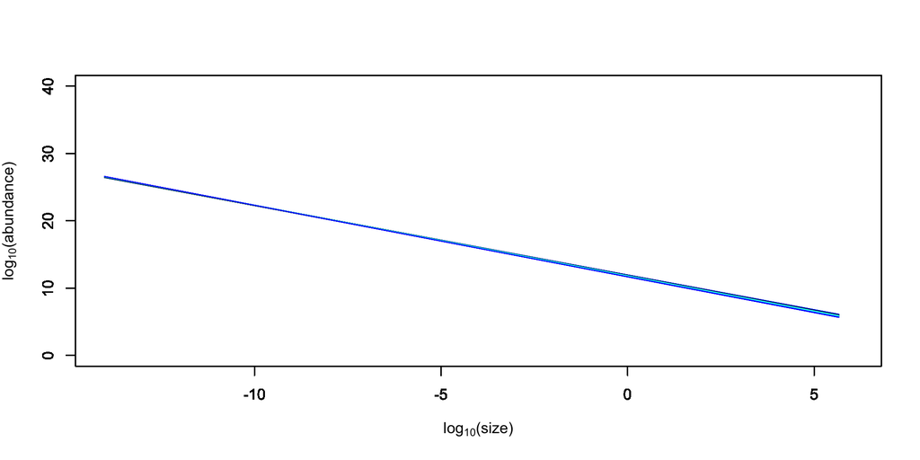

```r
for (t in seq(1950,2099,1)){
  plot(log10(size), IPSL_picon_n_pp_array[t-1949,], type = "l", col = "black", xlim = c(-14,6), ylim = c(0,40), xlab = " ", ylab = " ")
  par(new = TRUE)
  plot(log10(size), IPSL_CCscenario_126[t-1949,], type = "l", col = "cyan", xlim = c(-14,6), ylim = c(0,40), xlab = " ", ylab = " ")
  par(new = TRUE)
  plot(log10(size), IPSL_CCscenario_585[t-1949,], type = "l", col = "blue", xlim = c(-14,6), ylim = c(0,40), xlab = " ", ylab = " ")
  par(new = TRUE)
}
plot(log10(size), IPSL_picon_n_pp_array[2100-1949,], type = "l", col = "black", xlim = c(-14,6), ylim = c(0,40), xlab = " ", ylab = " ")
par(new = TRUE)
plot(log10(size), IPSL_CCscenario_126[2100-1949,], type = "l", col = "cyan", xlim = c(-14,6), ylim = c(0,40), xlab = " ", ylab = " ")
par(new = TRUE)
plot(log10(size), IPSL_CCscenario_585[2100-1949,], type = "l", col = "blue", xlim = c(-14,6), ylim = c(0,40), xlab = expression('log'[10]*'(size)'), ylab = expression('log'[10]*'(abundance)'))
```

That looks alright, too. Let’s save the files.

```r
write.table(GFDL_picon_n_pp_array, file = "GFDL_n_pp_array_PIcontrol_scaled_S1.0I0.85.dat", quote = FALSE, row.names = TRUE, col.names = TRUE)
write.table(GFDL_hist_n_pp_array, file = "GFDL_n_pp_array_hist_scaled_S1.0I0.85.dat", quote = FALSE, row.names = TRUE, col.names = TRUE)
write.table(GFDL_ssp126_n_pp_array, file = "GFDL_n_ppp_array_ssp126_scaled_S1.0I0.85.dat", quote = FALSE, row.names = TRUE, col.names = TRUE)
write.table(GFDL_ssp585_n_pp_array, file = "GFDL_n_pp_array_ssp585_scaled_S1.0I0.85.dat", quote = FALSE, row.names = TRUE, col.names = TRUE)
write.table(GFDL_CCscenario_126, file = "GFDL_n_pp_array_CCscenario_126_scaled_S1.0I0.85.dat", quote = FALSE, row.names = TRUE, col.names = TRUE)
write.table(GFDL_CCscenario_585, file = "GFDL_n_pp_array_CCscenario_585_scaled_S1.0I0.85.dat", quote = FALSE, row.names = TRUE, col.names = TRUE)

write.table(IPSL_picon_n_pp_array, file = "IPSL_n_pp_array_PIcontrol_scaled_S1.0I0.85.dat", quote = FALSE, row.names = TRUE, col.names = TRUE)
write.table(IPSL_hist_n_pp_array, file = "IPSL_n_pp_array_hist_scaled_S1.0I0.85.dat", quote = FALSE, row.names = TRUE, col.names = TRUE)
write.table(IPSL_ssp126_n_pp_array, file = "IPSL_n_ppp_array_ssp126_scaled_S1.0I0.85.dat", quote = FALSE, row.names = TRUE, col.names = TRUE)
write.table(IPSL_ssp585_n_pp_array, file = "IPSL_n_pp_array_ssp585_scaled_S1.0I0.85.dat", quote = FALSE, row.names = TRUE, col.names = TRUE)
write.table(IPSL_CCscenario_126, file = "IPSL_n_pp_array_CCscenario_126_scaled_S1.0I0.85.dat", quote = FALSE, row.names = TRUE, col.names = TRUE)
write.table(IPSL_CCscenario_585, file = "IPSL_n_pp_array_CCscenario_585_scaled_S1.0I0.85.dat", quote = FALSE, row.names = TRUE, col.names = TRUE)
```